# personal site

YJW

2021/10/10

# **鮪魚三明治ㄉ小檔案**

## 基本資料

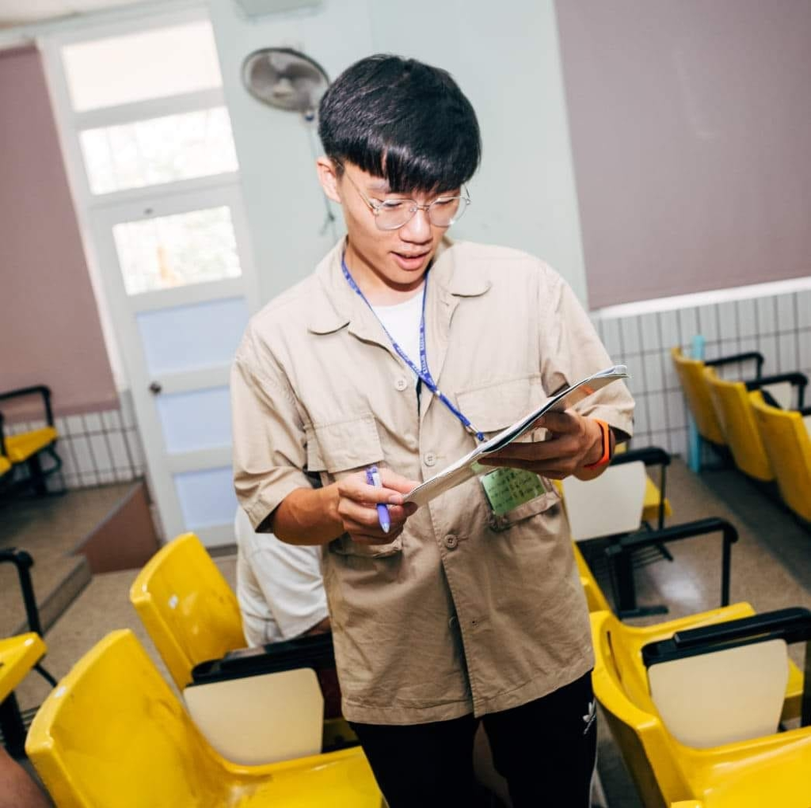

名前：于 治維

愛称：マグロ、鮪魚、鮪魚三明治、鮪明治、干智障(誤)

Name：Yu, Jhih-Wei (Jeff)

生日：1999-11-24

大學：國立成功大學

科系：生物醫學工程學系，雙主修：心理系

E-mail：c54076055@gmail.com

程式能力：C/C++、Python (tensorflow)、R

語言能力：中文(母語)、英文(GEPT中級)、日文(N3)

## 興趣分享

### Virtual Youtuber

**茸茸鼠/もちこまめ**

[figure not shown]

comame

中文超輪轉的日本Vtuber

[channel link](https://www.youtube.com/channel/UCBLqkkSpOi6a95Lf4BsTh7Q)

**Nanashi Mumei**

[figure not shown]

> 「議會」的一員，是一個被人類創造並崇尚「文明」概念的守護者。

> 她非常的博學多識且愛好旅行。但由於見識得過多，聽聞過太多，體驗經歷了太多，反而忘記了大部分的事，甚至連她自己真實的名子也都忘了。與其他議員不同的地方在於，她是人類的誕生與存在的證明，這也是她與其他概念生命體的差別。

> 「文明」是人類所創造，象徵著祈求智慧的生命而產生的。由於她並非由「諸神」所創造的概念，因此她選擇了人類智慧的代表動物貓頭鷹為自身的外觀。她，善良、勤奮、聰穎，身上並有著奇妙不可思議令人憐憫的嬌柔氣息。

> 長年獨自的漂泊旅途，多少讓她感受到了寂寞。因此她選中了人類「文明」中最重要的代表－紙作為朋友。「就算變得破破爛爛，但是一旦是朋友，終身都是朋友･･･。」